# Model Selection: Lasso

## Where are we?

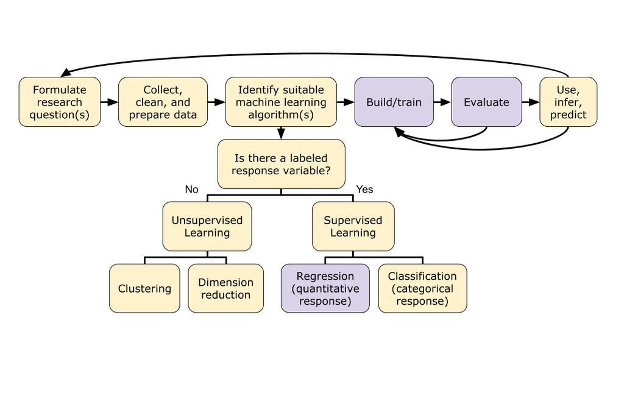

**Model Selection**

- Subset selection: forward and backward stepwise selection.
- Shrinkage/regularization: LASSO, ridge, elastic net
- Dimension reduction: principal components regression

## Review of linear models

The estimated coefficients, \(\hat{\beta_1}, \hat{\beta_2}..., \hat{\beta_p}\), are those that minimize the residual sum of squares:

\[ RSS = \sum_{i = 1}^n \Big[y_i - \big(\beta_0 + \beta_1 x_{i1} + ... + \beta_p x_{ip} \big) \Big]^2 = \sum_{i = 1}^n \Big(y_i - \beta_0 - \sum_{j=1}^p \beta_j x_{ij} \Big)^2 \]

## LASSO

The **L**east **A**bsolute **S**hrinkage and **S**election **O**perator finds \(\hat{\beta_1}, \hat{\beta_2}..., \hat{\beta_p}\) by minimizing:

\[ \begin{align} \sum_{i = 1}^n \Big(y_i - \beta_0 - \sum_{j=1}^p \beta_j x_{ij} \Big)^2 & + \lambda \sum_{j=1}^p |\beta_j|, \text{ where } \lambda\ge 0 \\ \text{RSS} \ \ \ \ \ \ \ \ \ \ \ \ \ \ \ \ & + \ \ \text{penalty} \end{align} \]

**Competing criteria**:

- RSS is small when coefficients fit data (ie. the more variables the better).
- Penalty is small when coefficients are small - it is smallest when they are all 0!

## Tuning

\[ \begin{align} \sum_{i = 1}^n \Big(y_i - \beta_0 - \sum_{j=1}^p \beta_j x_{ij} \Big)^2 & + \lambda \sum_{j=1}^p |\beta_j|, \text{ where } \lambda\ge 0 \\ \text{RSS} \ \ \ \ \ \ \ \ \ \ \ \ \ \ \ \ & + \ \ \text{penalty} \end{align} \]

**The extremes**: when \(\lambda = 0\) - OLS estimates and all coefficients are included, when \(\lambda = \infty\) - all coefficients are 0 and only an intercept.

**Ideal**: choose \(\lambda\) so some of the coefficients will shrink to zero. How? Use cross-validation!

**Scale variables**: make all variables have mean 0 and standard deviation 1 so they are penalized “fairly”.

## Simple example

| lambda | intercept | x1 | x2yes |
| --- | --- | --- | --- |
| 8.49 | 24.77 | 0.00 | 0.00 |
| 1.59 | 12.86 | 2.41 | 0.00 |
| 0.25 | 10.05 | 2.88 | 1.09 |
| 0.04 | 9.50 | 2.96 | 1.52 |

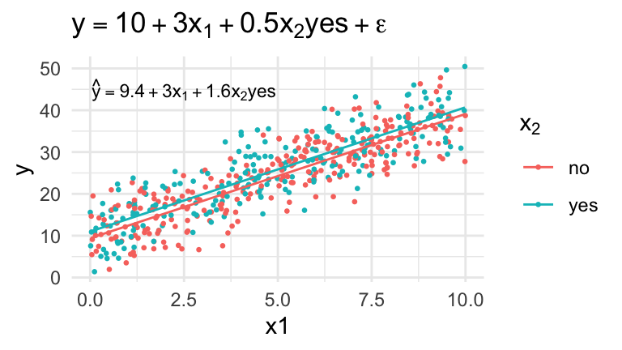

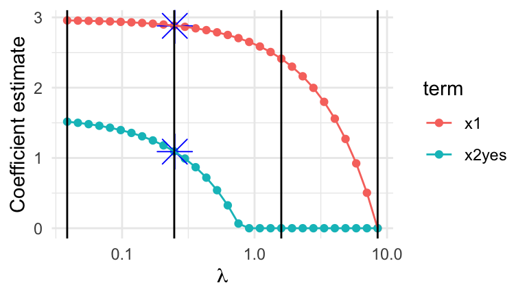

## More complex example - simulated credit data

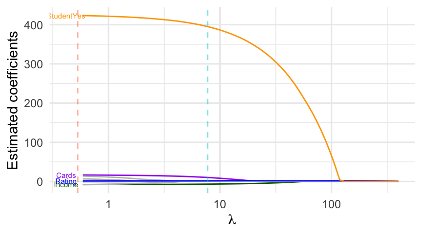

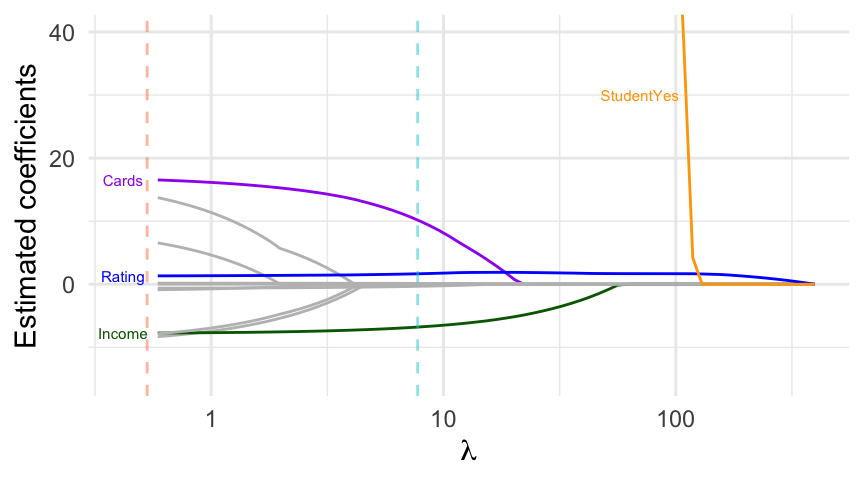

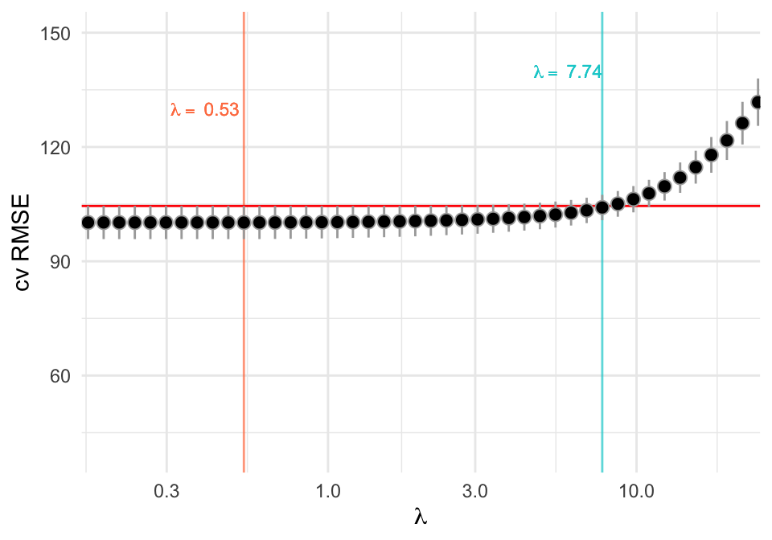